# Predicting median income in USA with the usage of spatially lagged linear model

## Comparing map plots - Median income in the US vs Spatially lagged median income in the US

#### Note that the second plot (spatially lagged median income) is much more clustered as it should be

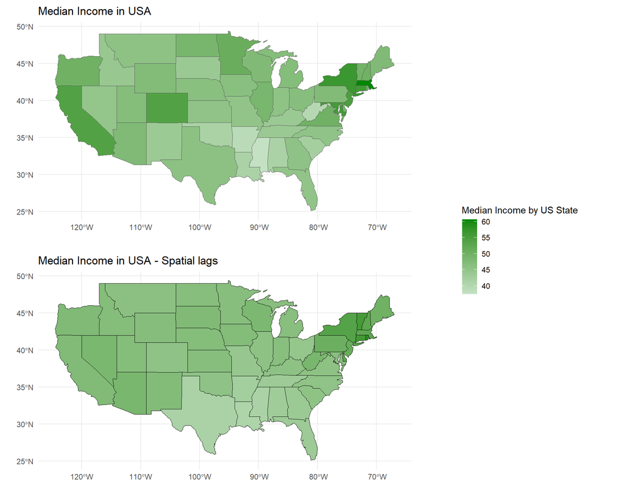

```r
plot1<- ggplot(all_data,aes(fill=median_income,
                       label=median_income)) +
  geom_sf()+
 #geom_sf_label(fun.geometry = sf::st_centroid,size=3,fill="white") +
  scale_fill_gradient(name = "Median Income by US State", low = "#C4E1C4", high = "#008802") +
  labs(title="Median Income in USA",
       x="",
       y="") +
  theme(plot.title = element_text(size=20,color="black"),
        legend.title = element_text(size=16,color="black"),
        legend.text = element_text(size=16,color="black"),
        legend.position = "bottom",
        plot.caption=element_text(size=16),
        text = element_text(family = "Times New Roman")) + theme_minimal()


legend <- get_legend(plot1)

plot2 <-income_lags %>%
  ggplot(aes(fill=income_lag)) +
  geom_sf(color="black",lwd=0.1) +
 #geom_sf_label(fun.geometry = sf::st_centroid,size=3,fill="white") +
  scale_fill_gradient(name = "Median Income by US State", low = "#C4E1C4", high = "#008802",limits= range(income_data$median_income)) +
  labs(title="Median Income in USA - Spatial lags",
       x="",
       y="") +
  theme(plot.title = element_text(size=20,color="black"),
        legend.title = element_text(size=16,color="black"),
        legend.text = element_text(size=16,color="black"),
        legend.position = "bottom",
        plot.caption=element_text(size=16),
        text = element_text(family = "Times New Roman")) + theme_minimal()


plot1 <- plot1 +theme(legend.position = "none")
plot2 <- plot2 +theme(legend.position = "none")


combined_plot <- plot_grid(plot1,plot2,ncol=1)

final_plot <- plot_grid(
  combined_plot,
  legend,
  ncol = 2,
  rel_widths = c(2,1))


print(final_plot)
```

## Creating a linear model WITHOUT special dependence

```r
all_data %>%
  as_tibble() %>%
  head()
```

```
## # A tibble: 6 × 14
##   id    name        density median_income urbanization density_mi2 median_age
##   <chr> <chr>         <dbl>         <dbl>        <dbl>       <dbl>      <dbl>
## 1 01    Alabama        94.6          41.4        0.577         101       39.3
## 2 04    Arizona        57.0          47.7        0.893          65       38.8
## 3 05    Arkansas       56.4          39.1        0.555          59       38.4
## 4 06    California    242.           54.0        0.942         250       37.6
## 5 08    Colorado       49.3          54.0        0.86           57       37.5
## 6 09    Connecticut   739.           56.1        0.863         747       41.2
## # ℹ 7 more variables: perc_bach_degree <dbl>, total_crimes_100_000 <dbl>,
## #   unemp_rate <dbl>, `% of national` <dbl>,
## #   `Foreign-born-population (%)` <dbl>, life_expectancy <dbl>,
## #   geometry <MULTIPOLYGON [°]>
```

#median_income, per bach degree + unemp rate

```r
all_data
```

```
## Simple feature collection with 47 features and 13 fields
## Geometry type: MULTIPOLYGON
## Dimension:     XY
## Bounding box:  xmin: -124.5532 ymin: 25.12078 xmax: -66.9796 ymax: 49.38362
## Geodetic CRS:  WGS 84
## First 10 features:
##    id        name density median_income urbanization density_mi2 median_age
## 1  01     Alabama   94.65         41.35        0.577         101       39.3
## 2  04     Arizona   57.05         47.68        0.893          65       38.8
## 3  05    Arkansas   56.43         39.06        0.555          59       38.4
## 4  06  California  241.70         54.03        0.942         250       37.6
## 5  08    Colorado   49.33         54.05        0.860          57       37.5
## 6  09 Connecticut  739.10         56.13        0.863         747       41.2
## 7  10    Delaware  464.30         49.28        0.826         529       41.5
## 8  12     Florida  353.40         45.07        0.915         422       42.6
```

[output cut: 24 more lines]

```r
mod1 <- lm(data = all_data, formula = median_income ~  perc_bach_degree  + `% of national` + urbanization)
```

```r
summary(mod1)
```

```
##
## Call:
## lm(formula = median_income ~ perc_bach_degree + `% of national` +
##     urbanization, data = all_data)
##
## Residuals:
##     Min      1Q  Median      3Q     Max
## -3.3440 -1.3232 -0.3599  1.2787  4.1656
##
## Coefficients:
##                  Estimate Std. Error t value Pr(>|t|)
## (Intercept)       20.6346     1.9177  10.760 8.91e-14 ***
## perc_bach_degree  63.0599     5.1617  12.217 1.42e-15 ***
## `% of national`    0.1545     0.1272   1.215  0.23094
## urbanization       6.5154     2.3546   2.767  0.00831 **
## ---
## Signif. codes:  0 '***' 0.001 '**' 0.01 '*' 0.05 '.' 0.1 ' ' 1
##
## Residual standard error: 1.967 on 43 degrees of freedom
## Multiple R-squared:  0.8459, Adjusted R-squared:  0.8352
## F-statistic: 78.69 on 3 and 43 DF,  p-value: < 2.2e-16
```

## Creating a linear model WITH spatial dependence

#### Moran test for regression residuals

#### H0: No spatial dependence in regression residuals

#### Since p-value < 0.05, it should be concluded that there exists a spatial dependence within linear regression’s residuals, which means that a spatial linear model would be better than “default” linear regression model

```r
lm.morantest(mod1,listw = nb2listw(nb))
```

```
##
##  Global Moran I for regression residuals
##
## data:
## model: lm(formula = median_income ~ perc_bach_degree + `% of national`
## + urbanization, data = all_data)
## weights: nb2listw(nb)
##
## Moran I statistic standard deviate = 2.9717, p-value = 0.001481
## alternative hypothesis: greater
## sample estimates:
## Observed Moran I      Expectation         Variance
##       0.24222355      -0.03956834       0.00899156
```

## Creating SAR spatial lag model

#### Formula

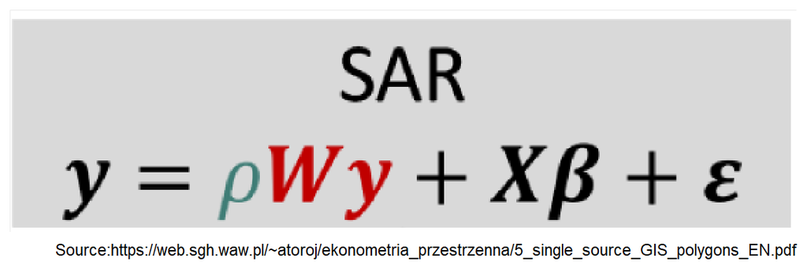

```r
ggplot() +
    background_image(readPNG("wzor.png")) +
  labs(caption = "Source:https://web.sgh.waw.pl/~atoroj/ekonometria_przestrzenna/5_single_source_GIS_polygons_EN.pdf")
```

##### The result is the sum of multiplication of weights and Y values for each neighbor, scaled with with Rho + X variables multiplied by their coefficients

```r
all_data
```

```
## Simple feature collection with 47 features and 13 fields
## Geometry type: MULTIPOLYGON
## Dimension:     XY
## Bounding box:  xmin: -124.5532 ymin: 25.12078 xmax: -66.9796 ymax: 49.38362
## Geodetic CRS:  WGS 84
## First 10 features:
##    id        name density median_income urbanization density_mi2 median_age
## 1  01     Alabama   94.65         41.35        0.577         101       39.3
## 2  04     Arizona   57.05         47.68        0.893          65       38.8
## 3  05    Arkansas   56.43         39.06        0.555          59       38.4
## 4  06  California  241.70         54.03        0.942         250       37.6
## 5  08    Colorado   49.33         54.05        0.860          57       37.5
## 6  09 Connecticut  739.10         56.13        0.863         747       41.2
## 7  10    Delaware  464.30         49.28        0.826         529       41.5
## 8  12     Florida  353.40         45.07        0.915         422       42.6
```

[output cut: 24 more lines]

### Relationship between median income and independent variables

[figure not shown]

```r
p1 <- plot(
  all_data$perc_bach_degree,
  all_data$median_income,
  xlab = "% with Bachelor's Degree",
  ylab = "unemp_rate",
  main = "Scatterplot of % with Bachelor's Degree vs. unemp_rate",
  pch = 19,
  col = "blue"
)
```

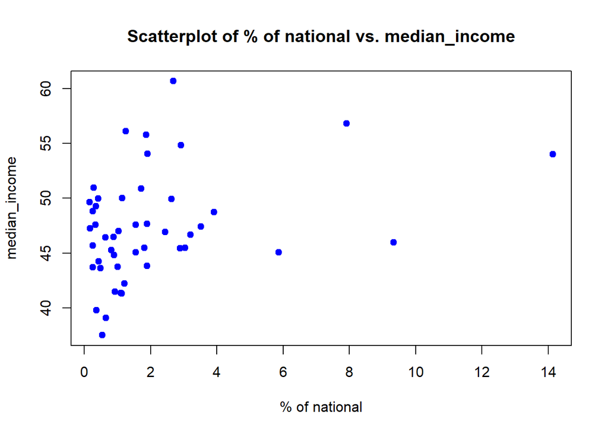

```r
p2 <- plot(
  all_data$`% of national`,
  all_data$median_income,
  xlab = "% of national",
  ylab = "median_income",
  main = "Scatterplot of % of national vs. median_income",
  pch = 19,
  col = "blue"
)
```

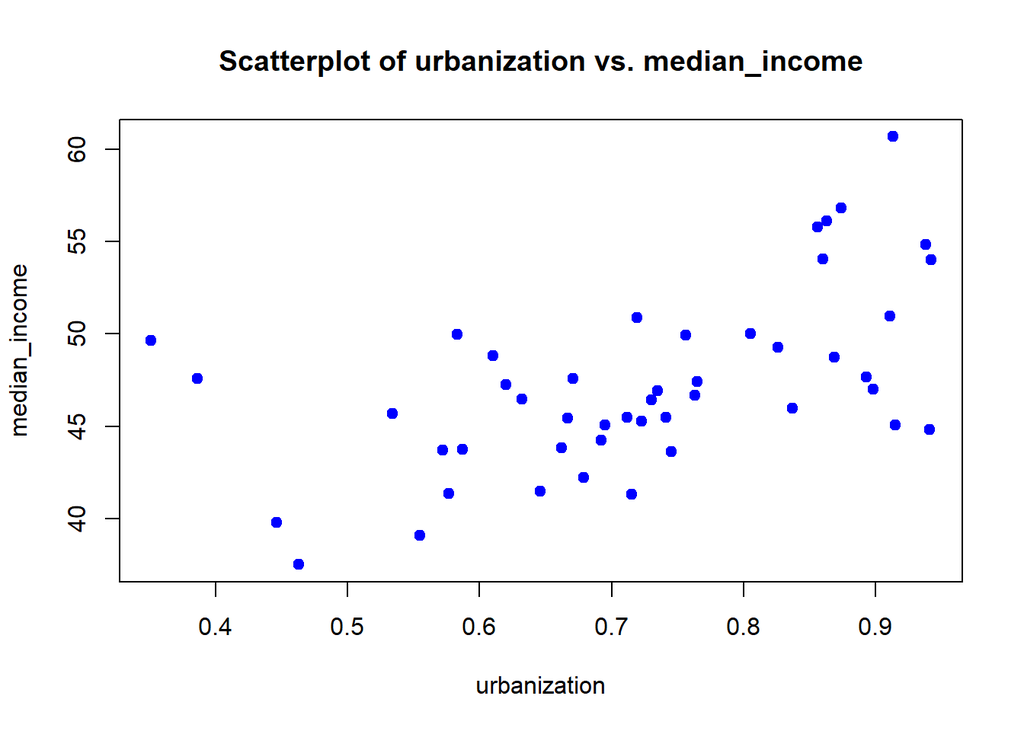

```r
p3<-plot(
  all_data$urbanization,
  all_data$median_income,
  xlab = "urbanization",
  ylab = "median_income",
  main = "Scatterplot of urbanization vs. median_income",
  pch = 19,
  col = "blue"
)
```

```r
p1 + p2 + p3
```

```
## integer(0)
```

```r
all_data
```

```
## Simple feature collection with 47 features and 13 fields
## Geometry type: MULTIPOLYGON
## Dimension:     XY
## Bounding box:  xmin: -124.5532 ymin: 25.12078 xmax: -66.9796 ymax: 49.38362
## Geodetic CRS:  WGS 84
## First 10 features:
##    id        name density median_income urbanization density_mi2 median_age
## 1  01     Alabama   94.65         41.35        0.577         101       39.3
## 2  04     Arizona   57.05         47.68        0.893          65       38.8
## 3  05    Arkansas   56.43         39.06        0.555          59       38.4
## 4  06  California  241.70         54.03        0.942         250       37.6
## 5  08    Colorado   49.33         54.05        0.860          57       37.5
## 6  09 Connecticut  739.10         56.13        0.863         747       41.2
## 7  10    Delaware  464.30         49.28        0.826         529       41.5
## 8  12     Florida  353.40         45.07        0.915         422       42.6
```

[output cut: 24 more lines]

```r
mod_spatial <- lagsarlm(formula = median_income ~  perc_bach_degree  + urbanization + `% of national` ,
    data = all_data,
    listw = nb2listw(nb))
```

```r
summary(mod_spatial,Nagelkerke = TRUE)
```

```
##
## Call:lagsarlm(formula = median_income ~ perc_bach_degree + urbanization +
##     `% of national`, data = all_data, listw = nb2listw(nb))
##
## Residuals:
##       Min        1Q    Median        3Q       Max
## -2.728270 -1.141768 -0.032824  1.258781  4.221570
##
## Type: lag
## Coefficients: (asymptotic standard errors)
##                  Estimate Std. Error z value  Pr(>|z|)
## (Intercept)      10.24058    3.01778  3.3934 0.0006903
## perc_bach_degree 52.39984    4.89237 10.7105 < 2.2e-16
## urbanization      6.12650    1.92060  3.1899 0.0014233
## `% of national`   0.25985    0.10585  2.4548 0.0140952
##
## Rho: 0.298, LR test value: 14.028, p-value: 0.00018006
## Asymptotic standard error: 0.073189
##     z-value: 4.0716, p-value: 4.6688e-05
## Wald statistic: 16.578, p-value: 4.6688e-05
##
## Log likelihood: -89.37773 for lag model
## ML residual variance (sigma squared): 2.5677, (sigma: 1.6024)
## Nagelkerke pseudo-R-squared: 0.88568
## Number of observations: 47
## Number of parameters estimated: 6
## AIC: 190.76, (AIC for lm: 202.78)
## LM test for residual autocorrelation
## test value: 0.15689, p-value: 0.69204
```

#### Nagelkerke pseudo-R-squared is higher than R^2 (0.88568 compared to 0.8352 in the OLS model)

#### All variables in the SAR model are significant.

## Direct and indirect effect

#### Due to the feedback loop (global spatial lag was used), it is needed to compute the direct (the impact of a particular variable on the Y variable in a particular neighbor) and the indirect effect (the impact of a particular variable in the neighbors of a particular neighbor on the Y value of that neighbor)

```r
impacts(mod_spatial,listw = nb2listw(nb))
```

```
## Impact measures (lag, exact):
##                      Direct  Indirect      Total
## perc_bach_degree 53.6397968 21.003648 74.6434453
## urbanization      6.2714761  2.455712  8.7271879
## `% of national`   0.2659969  0.104156  0.3701528
```

### Interpretation regarding the direct effect

#### If perc_bach_degree increases by 1 unit, median income will increase by 53.64, holding other variables constant, in the same spatial unit.

#### If % of national increases by 1 unit, median incomee will increase by 0.27, holding other variables constant in the same spatial unit

#### If urbanization increases by 1 unit, median income will increase by 6.27

### Interpretation regarding the indirect effect

#### If perc_bach_degree increases by 1 unit, median income will increase by 21.00 in neighboring units

#### If % of national increases by 1 unit, median income will increase by 0.10 in neighboring units

#### If urbanization increases by 1 unit, median income will increase by 2.45 in neighboring units